# HW 7

### Enter your name and EID here: Andy Park, AP59864

**You will submit this homework assignment as a pdf file on Gradescope.**

*For all questions, include the R commands/functions that you used to find your answer (show R chunk). Answers without supporting code will not receive credit. Write full sentences to describe your findings.*

We will use the packages `tidyverse` and `plotROC` for this assignment. If you do not have the `plotROC` package (i.e. loading the package with `library()` produces an error), then you should install it separately before doing this assignment.

```r
# Load packages
library(tidyverse)
library(plotROC)
```

## Question 1: (4 pts)

We will use the `pokemon` dataset for this assignment:

```r
# Upload data from GitHub
pokemon <- read_csv("https://raw.githubusercontent.com/laylaguyot/datasets/main//pokemon.csv")

# Take a look
head(pokemon)
```

```
## # A tibble: 6 × 13
##   Number Name           Type1 Type2 Total    HP Attack Defense SpAtk SpDef Speed
##    <dbl> <chr>          <chr> <chr> <dbl> <dbl>  <dbl>   <dbl> <dbl> <dbl> <dbl>
## 1      1 Bulbasaur      Grass Pois…   318    45     49      49    65    65    45
## 2      2 Ivysaur        Grass Pois…   405    60     62      63    80    80    60
## 3      3 Venusaur       Grass Pois…   525    80     82      83   100   100    80
## 4      3 VenusaurMega … Grass Pois…   625    80    100     123   122   120    80
## 5      4 Charmander     Fire  <NA>    309    39     52      43    60    50    65
## 6      5 Charmeleon     Fire  <NA>    405    58     64      58    80    65    80
## # ℹ 2 more variables: Generation <dbl>, Legendary <lgl>
```

Recode the variable `Legendary`, taking a value of 0 if a pokemon is not legendary and a value of 1 if it is. Save the resulting data as `my_pokemon`.

```r
# Recode Legendary column to be binary
my_pokemon <- pokemon %>%
  mutate(Legendary = if_else(Legendary, 1, 0))
```

Visualize the linear relationship between `Attack` and `HP` (hit points) for each legendary status.

*Hint: For the plot, convert the legendary status binary variable to a factor using `as.factor()`.*

Do `Attack` and `HP` seem to predict Legendary status? Comment with what you see in the visualization.

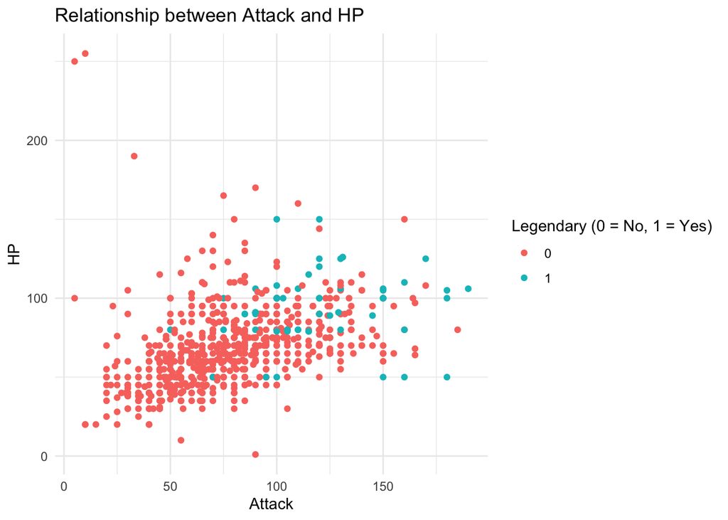

```r
# Create a scatter plot for Attack vs. HP colored by Legendary status
ggplot(my_pokemon, aes(x = Attack, y = HP, color = as.factor(Legendary))) +
  geom_point() +
  labs(x = "Attack",
       y = "HP",
       color = "Legendary (0 = No, 1 = Yes)",
       title = "Relationship between Attack and HP") +
  theme_minimal()
```

**The scatter plot shows that both nonlegendary and legendary pokemon cover a similar range of Attack and HP values. There is some separation in certain regions, but overall, there is substantial overlap between the two groups. This suggests that relying solely on Attack and HP values may not be sufficient for clearly predicting Legendary status.**

## Question 2: (2 pt)

Let’s predict `Legendary` status using a linear regression model with `Attack` and `HP` in `my_pokemon`. Fit this model, call it `pokemon_lin`, and write its equation.

```r
# Fit a linear regression model to predict Legendary status using Attack and HP
pokemon_lin <- lm(Legendary ~ Attack + HP, data = my_pokemon)
summary(pokemon_lin)
```

```
##
## Call:
## lm(formula = Legendary ~ Attack + HP, data = my_pokemon)
##
## Residuals:
##      Min       1Q   Median       3Q      Max
## -0.40650 -0.12385 -0.05025  0.01914  0.97201
##
## Coefficients:
##               Estimate Std. Error t value Pr(>|t|)
## (Intercept) -0.2201775  0.0289417  -7.608 7.88e-14 ***
## Attack       0.0023563  0.0003054   7.715 3.61e-14 ***
## HP           0.0016644  0.0003882   4.288 2.03e-05 ***
## ---
## Signif. codes:  0 '***' 0.001 '**' 0.01 '*' 0.05 '.' 0.1 ' ' 1
##
## Residual standard error: 0.254 on 797 degrees of freedom
## Multiple R-squared:  0.1392, Adjusted R-squared:  0.137
## F-statistic: 64.42 on 2 and 797 DF,  p-value: < 2.2e-16
```

## Question 3: (3 pts)

Choose a pokemon whose name starts with the same letter as yours. Take a look at its stats and, using the equation of your model from the previous question, predict the legendary status of this pokemon, “by hand” (multiplying the predictors with the estimated coefficients):

```r
# Choose a pokemon whose name starts with A (Andy).
selected_pokemon <- my_pokemon %>% filter(Name == "Articuno")
selected_pokemon
```

```
## # A tibble: 1 × 13
##   Number Name     Type1 Type2  Total    HP Attack Defense SpAtk SpDef Speed
##    <dbl> <chr>    <chr> <chr>  <dbl> <dbl>  <dbl>   <dbl> <dbl> <dbl> <dbl>
## 1    144 Articuno Ice   Flying   580    90     85     100    95   125    85
## # ℹ 2 more variables: Generation <dbl>, Legendary <dbl>
```

Check your answer by using `predict()` with the argument `newdata =`:

```r
# Extract coefficients from the linear model
coefs <- coef(pokemon_lin)
coefs
```

```
##  (Intercept)       Attack           HP
## -0.220177510  0.002356294  0.001664444
```

```r
manual_prediction <- coefs[1] + coefs[2] * selected_pokemon$Attack + coefs[3] * selected_pokemon$HP
manual_prediction
```

```
## (Intercept)
##   0.1299075
```

```r
predict_prediction <- predict(pokemon_lin, newdata = selected_pokemon)
predict_prediction
```

```
##         1
## 0.1299075
```

Was your pokemon predicted to be legendary (i.e. is the prediction close to 0 or 1)? Why or why not? Does it match character’s Legendary status in dataset?

## Question 4: (2 pts)

We can measure how far off our predictions are from reality with residuals. Use `resid()` to find the residuals of each pokemon in the dataset then find the sum of all residuals. What is the sum of all the residuals. Why does it make sense?

```r
# Get residuals from the linear model and sum it
residuals_lin <- resid(pokemon_lin)

sum_residuals <- sum(residuals_lin)
sum_residuals
```

```
## [1] -7.654034e-15
```

**The sum of all the residuals is close to zero. This result makes sense because, by construction, the ordinary least squares method ensures that the sum of the residuals equals zero.**

## Question 5: (2 pts)

A logistic regression would be more appropriate to predict `Legendary` status since it can only take two values. Fit this new model with `Attack` and `HP`, call it `pokemon_log`, and write its equation. *Hint: the logit form is given by the R output.*

```r
# Fit a logistic regression model with binary outcome Legendary using Attack and HP
pokemon_log <- glm(Legendary ~ Attack + HP, data = my_pokemon, family = "binomial")
summary(pokemon_log)
```

```
##
## Call:
## glm(formula = Legendary ~ Attack + HP, family = "binomial", data = my_pokemon)
##
## Coefficients:
##              Estimate Std. Error z value Pr(>|z|)
## (Intercept) -7.659078   0.680595 -11.253  < 2e-16 ***
## Attack       0.032901   0.004431   7.425 1.12e-13 ***
## HP           0.025923   0.004982   5.203 1.96e-07 ***
## ---
## Signif. codes:  0 '***' 0.001 '**' 0.01 '*' 0.05 '.' 0.1 ' ' 1
##
## (Dispersion parameter for binomial family taken to be 1)
##
##     Null deviance: 450.90  on 799  degrees of freedom
## Residual deviance: 340.34  on 797  degrees of freedom
## AIC: 346.34
##
## Number of Fisher Scoring iterations: 6
```

```r
summary(pokemon_log)
```

```
##
## Call:
## glm(formula = Legendary ~ Attack + HP, family = "binomial", data = my_pokemon)
##
## Coefficients:
##              Estimate Std. Error z value Pr(>|z|)
## (Intercept) -7.659078   0.680595 -11.253  < 2e-16 ***
## Attack       0.032901   0.004431   7.425 1.12e-13 ***
## HP           0.025923   0.004982   5.203 1.96e-07 ***
## ---
## Signif. codes:  0 '***' 0.001 '**' 0.01 '*' 0.05 '.' 0.1 ' ' 1
##
## (Dispersion parameter for binomial family taken to be 1)
##
##     Null deviance: 450.90  on 799  degrees of freedom
## Residual deviance: 340.34  on 797  degrees of freedom
## AIC: 346.34
##
## Number of Fisher Scoring iterations: 6
```

## Question 6: (2 pts)

According to this new model, is the pokemon you chose in question 3 predicted to be legendary (i.e. probability is greater than 0.5)? Why or why not?

*Hint: you can use predict() with the arguments `newdata =` and `type = "response"`.*

```r
# Predict the probability of being legendary for the selected pokemon using the logistic regression model
logistic_prob <- predict(pokemon_log, newdata = selected_pokemon, type = "response")
logistic_prob
```

```
##          1
## 0.07381835
```

## Question 7: (3 pts)

Let’s compare the performance of these two models using ROC curves. On the same plot using `geom_roc()`, represent the ROC curve for predicting `Legendary` status based on the predictions from the linear regression in blue and another ROC curve based on the predictions from the logistic regression in orange.

*Hint: You will need to make predictions from both the `pokemon_lin` model object and the `pokemon_log` model object. For the `pokemon_log` model, make sure to make predictions using `type = "response"`.*

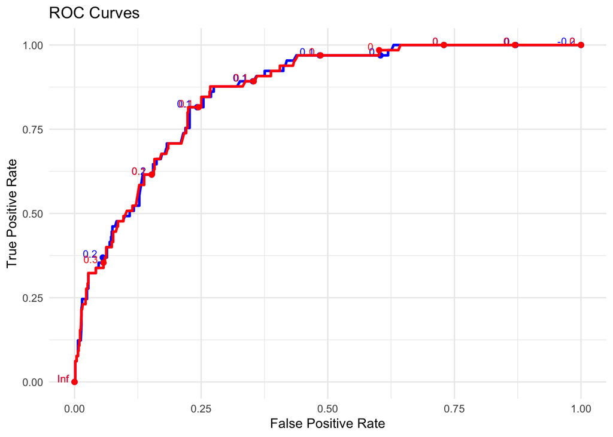

```r
# Create predictions from both models
my_pokemon <- my_pokemon %>%
  mutate(
    lin_pred = predict(pokemon_lin),
    log_pred = predict(pokemon_log, type = "response")
  )

# Create an ROC curve plot using geom_roc() from the plotROC package
ggplot(my_pokemon, aes(d = Legendary)) +
  geom_roc(aes(m = lin_pred), color = "blue", labelsize = 3) +
  geom_roc(aes(m = log_pred), color = "red", labelsize = 3) +
  labs(title = "ROC Curves",
       x = "False Positive Rate",
       y = "True Positive Rate") +
  theme_minimal()
```

## Formatting: (2 pts)

Comment your code, write full sentences, knit your file, and select all appropriate pages in Gradescope for each question!

[output not shown]